# Hands_on_III

Conchillo Robles, Júlia (julia.conchillorobles01@estudiant.upf.edu)

Last update: 27 marzo, 2026

# Exercise 1

**Build a Random Forest model to classify COVID-19 severity**

Using the training cohort provided in Supplementary Table 3, build a Random Forest classification model similar to the one in the publication to distinguish between non-Severe and Severe COVID-19 patients.

Report the following performance metrics from cross-validation:

- Confusion matrix
- Accuracy
- ROC curve and AUC

How well does the Random Forest model separate non-Severe from Severe patients based on proteomic profiles?

```r
# PATIENT METADATA DOWNLOAD and IMPORT

url_mmc1  <- "https://ars.els-cdn.com/content/image/1-s2.0-S0092867420306279-mmc1.xlsx"

file_mmc1 <- tempfile(fileext = ".xlsx") #Temporay file to store the Excel
GET(url_mmc1, write_disk(file_mmc1, overwrite = TRUE))
```

```
## Response [https://ars.els-cdn.com/content/image/1-s2.0-S0092867420306279-mmc1.xlsx]
##   Date: 2026-03-27 17:21
##   Status: 200
##   Content-Type: application/excel
##   Size: 36.9 kB
## <ON DISK>  /tmp/Rtmpgofy1A/file2d071b9ab169.xlsx
```

```r
raw_data <- read_excel(file_mmc1, sheet = 2, na = c("", "NA", "/"))
# DATA CLEANING

#Standarize column names
clean_data <- janitor::clean_names(raw_data, replace = c("\u03bc" = "micro"))

# Convert date columns to proper Date class regardless of their original format
date_vars <- c("admission_date", "onset_date_f", "date_of_progression_to_severe_state")

clean_data[date_vars] <- lapply(clean_data[date_vars], function(x) {
  if (inherits(x, "POSIXct") || inherits(x, "POSIXt") || inherits(x, "Date")) {
    as.Date(x)
  } else {
    as.Date(as.character(x))
  }
})

#Classification by groups
clean_data <- clean_data %>%
  mutate(
    group = case_when(
      group_d == 0 ~ "Healthy Control",
      group_d == 1 ~ "Non-COVID-19",
      group_d == 2 ~ "Non-severe",
      group_d == 3 ~ "Severe",
      TRUE ~ "Unknown"
    )
  ) %>%
  filter(group != "Unknown")

#Extraction of the needed columns: patient ID and severity for the training cohort
label_df <- clean_data %>%
  filter(covid_19_patients_corhort == "Training (C1)") %>% #only tarining cohort
  filter(group %in% c("Non-severe", "Severe")) %>% #only COVID-19 patients
  select(Sample = patient_id_a, Severity = group) %>%
  mutate(Sample = as.character(trimws(Sample)))

#Extraction of the needed columns: patient ID and severity for the test cohort (C2)
label_df_test <- clean_data %>%
  filter(covid_19_patients_corhort == "Test 1 (C2)") %>% #only test 1 cohort
  filter(group %in% c("Non-severe", "Severe")) %>% #only COVID-19 patients
  select(Sample = patient_id_a, Severity = group) %>%
  mutate(Sample = as.character(trimws(Sample)))

#Check class distribution in each cohort
print(label_df)
```

```
## # A tibble: 31 × 2
##    Sample Severity
##    <chr>  <chr>
##  1 XG1    Non-severe
##  2 XG2    Non-severe
##  3 XG3    Non-severe
##  4 XG4    Non-severe
##  5 XG5    Non-severe
##  6 XG6    Non-severe
##  7 XG7    Non-severe
##  8 XG8    Non-severe
##  9 XG9    Non-severe
## 10 XG10   Non-severe
## # ℹ 21 more rows
```

```r
print(table(label_df$Severity))
```

```
##
## Non-severe     Severe
##         18         13
```

```r
print(label_df_test)
```

```
## # A tibble: 10 × 2
##    Sample Severity
##    <chr>  <chr>
##  1 XG20   Non-severe
##  2 XG21   Non-severe
##  3 XG22   Non-severe
##  4 XG23   Non-severe
##  5 XG24   Non-severe
##  6 XG25   Non-severe
##  7 XG43   Severe
##  8 XG44   Severe
##  9 XG45   Severe
## 10 XG46   Severe
```

```r
print(table(label_df_test$Severity))
```

```
##
## Non-severe     Severe
##          6          4
```

```r
# TRAINING COHORT (Supplementary Table 3)


url_mmc3  <- "https://ars.els-cdn.com/content/image/1-s2.0-S0092867420306279-mmc3.xlsx"
file_mmc3 <- tempfile(fileext = ".xlsx")
GET(url_mmc3, write_disk(file_mmc3, overwrite = TRUE))
```

```
## Response [https://ars.els-cdn.com/content/image/1-s2.0-S0092867420306279-mmc3.xlsx]
##   Date: 2026-03-27 17:21
##   Status: 200
##   Content-Type: application/excel
##   Size: 549 kB
## <ON DISK>  /tmp/Rtmpgofy1A/file2d075b1e4d9d.xlsx
```

```r
#Read the protein/metabolite matrix sheet
df_raw <- read_excel(file_mmc3,
                     sheet     = "Prot_and_meta_matrix",
                     col_names = TRUE,
                     na        = c("", "NA", "#N/D"))
cat(nrow(df_raw), ncol(df_raw)) #dimentions
```

```
## 1639 33
```

```r
# DATA CLEANING (supplemetary table 3)

#The first row conatins the patients IDs
sample_ids <- as.character(df_raw[1, 3:ncol(df_raw)])
sample_ids <- trimws(sample_ids[!is.na(sample_ids)])

#All remaining rows are protein features
df_prot <- df_raw[2:nrow(df_raw), ]

#Features names: We use Gene Symbol (col 2), but if it says NA, we use Protein ID (col 1)
gene_names <- ifelse(
  is.na(df_prot[[2]]) | trimws(as.character(df_prot[[2]])) %in% c("NA", ""),
  as.character(df_prot[[1]]),
  as.character(df_prot[[2]])
)

# We keep only the first Gene Symbol name
gene_names <- sapply(strsplit(gene_names, ","), `[`, 1)
gene_names <- trimws(gene_names)
gene_names <- make.unique(gene_names, sep = "_")

#Numeric matrix: features x samples
mat_prot           <- apply(df_prot[, 3:(2 + length(sample_ids))], 2, as.numeric)
rownames(mat_prot) <- gene_names
colnames(mat_prot) <- sample_ids

#Transpose the matrix to have it in ML format (samples x features)
X_all <- as.data.frame(t(mat_prot))

cat(nrow(X_all), "samples x", ncol(X_all), "features\n")
```

```
## 31 samples x 1638 features
```

```r
# JOIN (proteomics with severity)


#Adding sample column to do the join
X_all$Sample <- rownames(X_all)

#Inner join keeps only patients present in both the expression matrix and the label table
df_model <- X_all %>%
  inner_join(label_df, by = "Sample")

#Encode severity as a factor with "Non-severe" as the reference level
df_model$Severity <- factor(df_model$Severity,
                            levels = c("Non-severe", "Severe"))

#Separate predictors (X) from the response variable (y)
X <- df_model %>% select(-Sample, -Severity)
y <- df_model$Severity

cat("Training cohort used for ML:", nrow(X), "samples x", ncol(X), "features\n")
```

```
## Training cohort used for ML: 31 samples x 1638 features
```

```r
table(y)
```

```
## y
## Non-severe     Severe
##         18         13
```

```r
# HYPERPARAMETER TUNING: mtry via 5-fold Stratified CV


# mtry controls how many features are randomly considered at each tree split.
# We evaluate a small grid and pick the value that maximises cross-validated AUC.

set.seed(42) #ensures reproducibility

p <- ncol(X)

#We use these candidate mtry values
mtry_grid <- unique(c(
  5,
  10,
  20,
  floor(sqrt(p))
))

mtry_grid <- mtry_grid[mtry_grid > 0 & mtry_grid <= p]

# Create 5 stratified folds
folds <- createFolds(y, k = 5, returnTrain = FALSE)

results <- data.frame(mtry = integer(), AUC = numeric())

for (m in mtry_grid) {

  cat("Testing mtry =", m, "\n")

  fold_probs <- list() #Stores predicted probabilities per fold
  fold_true  <- list() #Stores true labels per fold

  for (i in seq_along(folds)) {

    idx_test  <- folds[[i]]
    idx_train <- setdiff(seq_len(nrow(X)), idx_test)

    X_train <- X[idx_train, , drop = FALSE]
    X_test  <- X[idx_test, , drop = FALSE]
    y_train <- y[idx_train]
    y_test  <- y[idx_test]


#Preprocessing within fold to avoid data leakage

#keep proteins observed in at least 80% of training samples
  prot_keep <- colSums(!is.na(X_train)) >= 0.8 * nrow(X_train)
  X_train <- X_train[, prot_keep, drop = FALSE]
  X_test  <- X_test[, prot_keep, drop = FALSE]

#median imputation
  train_medians <- sapply(X_train, median, na.rm = TRUE)

  for (j in seq_along(train_medians)) {
    X_train[is.na(X_train[, j]), j] <- train_medians[j]
    X_test[is.na(X_test[, j]), j]   <- train_medians[j]
  }

#train the RF on this fold's training split
rf <- randomForest(
  x = X_train,
  y = y_train,
  ntree = 500,
  mtry = m,
  importance = TRUE
)

#predict probability of "Severe" class
probs <- predict(rf, X_test, type = "prob")[, "Severe"]

  fold_probs[[i]] <- probs
  fold_true[[i]]  <- y_test
  }

#Pool predictions across all folds and compute AUC
all_probs <- unlist(fold_probs)
all_true  <- factor(unlist(fold_true), levels = levels(y))

roc_obj <- roc(all_true, all_probs,
  levels = c("Non-severe", "Severe"),
  direction = "<",
  quiet = TRUE)

results <- rbind(results,
  data.frame(mtry = m, AUC = as.numeric(auc(roc_obj))))
}
```

```
## Testing mtry = 5
## Testing mtry = 10
## Testing mtry = 20
## Testing mtry = 40
```

```r
print(results)
```

```
##   mtry       AUC
## 1    5 0.8803419
## 2   10 0.9188034
## 3   20 0.8803419
## 4   40 0.8803419
```

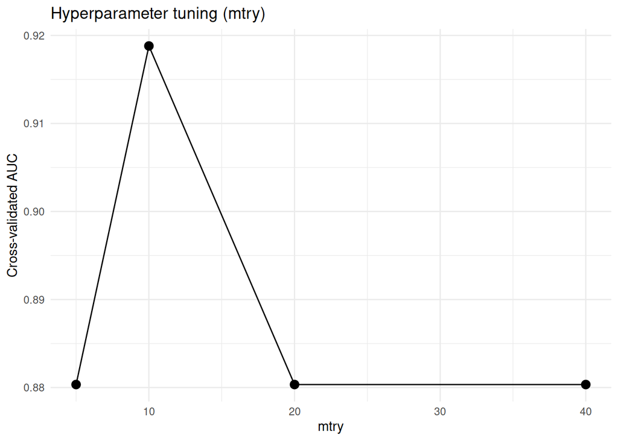

```r
#Plot AUC vs mtry to visualise the tuning
ggplot(results, aes(x = mtry, y = AUC)) +
  geom_line() +
  geom_point(size = 3) +
  theme_minimal() +
  labs(title = "Hyperparameter tuning (mtry)",
       x = "mtry",
       y = "Cross-validated AUC")
```

```r
#Select the mtry value with the highest AUC
best_mtry <- results$mtry[which.max(results$AUC)]
best_mtry
```

```
## [1] 10
```

```r
# FINAL 5-FOLD CV WITH BEST mtry


#Re-run the full cross-validation using the selected mtry

set.seed(42)

folds <- createFolds(y, k = 5, returnTrain = FALSE)

lista_preds <- list() #Class predictions per fold
lista_probs <- list() #Probability of "Severe" per fold
lista_true  <- list() #True labels per fold

for (i in seq_along(folds)) {

  idx_test  <- folds[[i]]
  idx_train <- setdiff(seq_len(nrow(X)), idx_test)

  X_train <- X[idx_train, , drop = FALSE]
  X_test  <- X[idx_test, , drop = FALSE]
  y_train <- y[idx_train]
  y_test  <- y[idx_test]

#Preprocessing within fold
prot_keep <- colSums(!is.na(X_train)) >= 0.8 * nrow(X_train)
X_train <- X_train[, prot_keep, drop = FALSE]
X_test  <- X_test[, prot_keep, drop = FALSE]

train_medians <- sapply(X_train, median, na.rm = TRUE)

for (j in seq_along(train_medians)) {
  X_train[is.na(X_train[, j]), j] <- train_medians[j]
  X_test[is.na(X_test[, j]), j]   <- train_medians[j]
}

rf_cv <- randomForest(
  x = X_train,
  y = y_train,
  ntree = 500,
  mtry = best_mtry
)

lista_preds[[i]] <- predict(rf_cv, X_test, type = "response")
lista_probs[[i]] <- predict(rf_cv, X_test, type = "prob")[, "Severe"]
lista_true[[i]]  <- y_test
}

#Concatenate results across all folds
all_preds <- factor(unlist(lista_preds), levels = levels(y))
all_probs <- unlist(lista_probs)
all_true  <- factor(unlist(lista_true), levels = levels(y))
```

```r
# EVALUATION METRICS


#Confusion matrix using "Severe" as the positive class
cm <- confusionMatrix(all_preds, all_true, positive = "Severe")
print(cm)
```

```
## Confusion Matrix and Statistics
##
##             Reference
## Prediction   Non-severe Severe
##   Non-severe         16      3
##   Severe              2     10
##
##                Accuracy : 0.8387
##                  95% CI : (0.6627, 0.9455)
##     No Information Rate : 0.5806
##     P-Value [Acc > NIR] : 0.002108
##
##                   Kappa : 0.6652
##
##  Mcnemar's Test P-Value : 1.000000
##
##             Sensitivity : 0.7692
##             Specificity : 0.8889
##          Pos Pred Value : 0.8333
##          Neg Pred Value : 0.8421
##              Prevalence : 0.4194
##          Detection Rate : 0.3226
##    Detection Prevalence : 0.3871
##       Balanced Accuracy : 0.8291
##
##        'Positive' Class : Severe
##
```

```r
#Compute ROC curve and AUC
roc_obj <- roc(all_true, all_probs,
               levels = c("Non-severe", "Severe"),
               direction = "<",
               quiet = TRUE)

roc_auc <- auc(roc_obj)

#Extract individual metrics for reporting
accuracy    <- unname(cm$overall["Accuracy"])
sensitivity <- unname(cm$byClass["Sensitivity"])
specificity <- unname(cm$byClass["Specificity"])
precision   <- unname(cm$byClass["Pos Pred Value"])
f1          <- unname(cm$byClass["F1"])

cat("Accuracy   :", round(accuracy, 3), "\n")
```

```
## Accuracy   : 0.839
```

```r
cat("Sensitivity:", round(sensitivity, 3), "\n")
```

```
## Sensitivity: 0.769
```

```r
cat("Specificity:", round(specificity, 3), "\n")
```

```
## Specificity: 0.889
```

```r
cat("Precision  :", round(precision, 3), "\n")
```

```
## Precision  : 0.833
```

```r
cat("F1         :", round(f1, 3), "\n")
```

```
## F1         : 0.8
```

```r
cat("AUC        :", round(as.numeric(roc_auc), 3), "\n")
```

```
## AUC        : 0.904
```

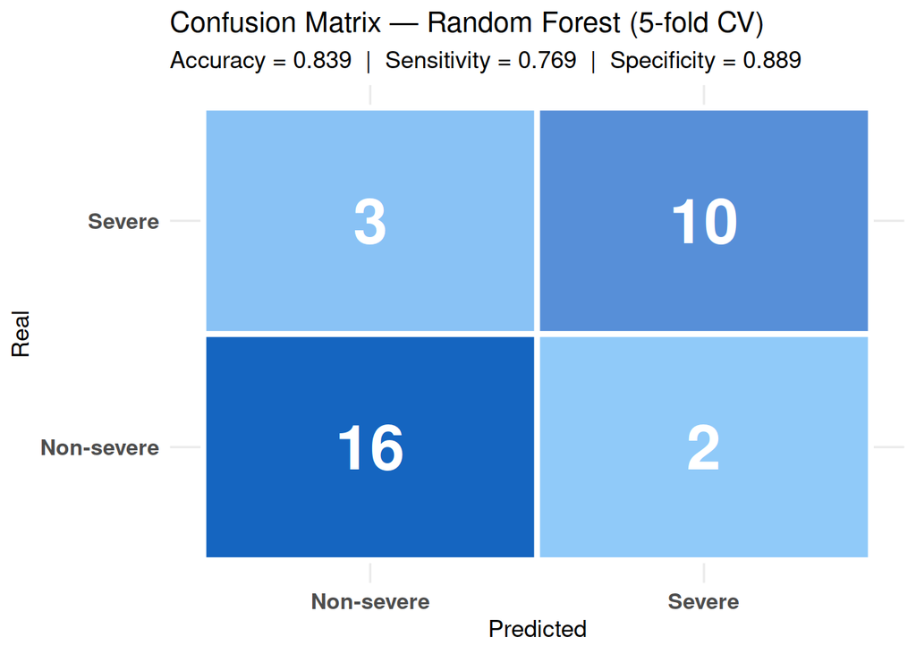

```r
# RESULTS VISUALIZATION


#Confusion Matrix
as.data.frame(cm$table) %>%
  rename(Predicho = Prediction, Real = Reference, N = Freq) %>%
  ggplot(aes(x = Predicho, y = Real, fill = N)) +
  geom_tile(color = "white", linewidth = 1.5) +
  geom_text(aes(label = N), size = 12, fontface = "bold", color = "white") +
  scale_fill_gradient(low = "#90CAF9", high = "#1565C0") +
  labs(
    title    = "Confusion Matrix — Random Forest (5-fold CV)",
    subtitle = sprintf("Accuracy = %.3f  |  Sensitivity = %.3f  |  Specificity = %.3f",
                       accuracy, sensitivity, specificity),
    x = "Predicted", y = "Real"
  ) +
  theme_minimal(base_size = 13) +
  theme(legend.position = "none",
        axis.text = element_text(size = 12, face = "bold"))
```

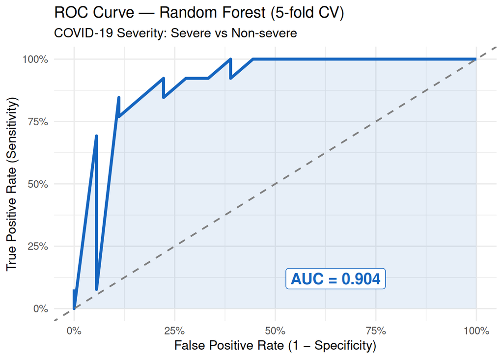

```r
#ROC curve
data.frame(
  FPR = 1 - roc_obj$specificities,
  TPR = roc_obj$sensitivities
) %>%
  ggplot(aes(x = FPR, y = TPR)) +
  geom_line(color = "#1565C0", linewidth = 1.4) +
  geom_ribbon(aes(ymin = 0, ymax = TPR), fill = "#1565C0", alpha = 0.10) +
  geom_abline(slope = 1, intercept = 0,
              linetype = "dashed", color = "gray50", linewidth = 0.8) +
  annotate("label", x = 0.65, y = 0.12,
           label   = sprintf("AUC = %.3f", roc_auc),
           size    = 5.5, color = "#1565C0", fontface = "bold",
           fill    = "white", label.size = 0.5) +
  scale_x_continuous(labels = percent_format(), limits = c(0, 1)) +
  scale_y_continuous(labels = percent_format(), limits = c(0, 1)) +
  labs(
    title    = "ROC Curve — Random Forest (5-fold CV)",
    subtitle = "COVID-19 Severity: Severe vs Non-severe",
    x = "False Positive Rate (1 − Specificity)",
    y = "True Positive Rate (Sensitivity)"
  ) +
  theme_minimal(base_size = 13)
```

```r
# FINAL MODEL TRAINED ON FULL TRAINING COHORT


#After CV evaluation, we retrain on ALL of C1 using best_mtry.
#This model is used for external prediction in Exercise 3.

#Apply the same preprocessing rules learned from the full training set
final_keep <- colSums(!is.na(X)) >= 0.8 * nrow(X)
X_final <- X[, final_keep, drop = FALSE]

#Compute and apply median imputation on the full training set
final_medians <- sapply(X_final, median, na.rm = TRUE)

for (j in seq_along(final_medians)) {
  X_final[is.na(X_final[, j]), j] <- final_medians[j]
}

#Train the final Random Forest on the complete C1 cohort
rf_final <- randomForest(
  x = X_final,
  y = y,
  ntree = 500,
  mtry = best_mtry,
  importance = TRUE
)

cat("Final model trained with", ncol(X_final), "proteins and mtry =", best_mtry, "\n")
```

```
## Final model trained with 1286 proteins and mtry = 10
```

# Exercise 2

**Identify and interpret the most important features**

Using the trained Random Forest model from Exercise 1, identify the 25 most important protein features contributing to the classification. Disccus their biological relevance.

Compare your selected features to the proteins reported by the authors in Supplementary Table 5.

```r
# FEATURE IMPORTANCE


#Extract Mean Decrease Gini from the final model
imp_df <- importance(rf_final, type = 2) %>%
  as.data.frame() %>%
  rownames_to_column("Proteina") %>%
  rename(Importancia = MeanDecreaseGini) %>%
  arrange(desc(Importancia)) #Sort from most to least important (higher value = greater contribution to node classification)

#Keep the top 25 proteins
top25_imp <- imp_df %>% slice_head(n = 25)

print(top25_imp)
```

```
##                    Proteina Importancia
## 1                      SAA2  0.17522238
## 2                  SERPING1  0.17231329
## 3                        C9  0.13436007
## 4                       ALB  0.12131178
## 5                        C6  0.12009514
## 6       N-acetylneuraminate  0.11317852
## 7                      SAA1  0.10287226
## 8                   mannose  0.09967089
## 9                 aspartate  0.08984925
## 10                     CPN1  0.08958121
## 11                     LRG1  0.08716080
## 12                      CRP  0.08643886
## 13                    APOL1  0.08399837
## 14                      LBP  0.08353705
## 15                       C2  0.07952167
## 16         3-hydroxylaurate  0.07849673
## 17     ceramide (d18:1/20:0  0.07463607
## 18 androsterone glucuronide  0.07373676
## 19                 SERPINA3  0.07188043
## 20                   MAN1A1  0.07146185
## 21                       TF  0.07109391
## 22                SERPINA10  0.07091168
## 23                      FN1  0.06929005
## 24  6-hydroxyindole sulfate  0.06916401
## 25                tartarate  0.06861293
```

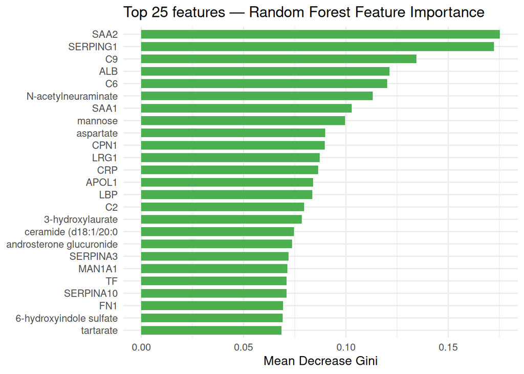

```r
ggplot(top25_imp, aes(x = reorder(Proteina, Importancia), y = Importancia)) +
  geom_col(fill = "#4CAF50", width = 0.7) +
  coord_flip() +
  labs(
    title    = "Top 25 features — Random Forest Feature Importance",
    x = NULL,
    y = "Mean Decrease Gini"
  ) +
  theme_minimal(base_size = 12)
```

The Random Forest model highlighted a set of proteins whose importance aligns closely with known pathophysiology of severe COVID-19. Among the top features, CRP, SAA1, and SAA2 stand out as classical acute-phase reactants that are robustly upregulated during systemic inflammation, consistent with the cytokine storm observed in severe disease. Components of the terminal complement cascade — C6 and C9 — were also highly ranked, supporting the hypothesis that uncontrolled complement activation contributes to tissue damage and respiratory failure in critical patients. Several serine protease inhibitors, including SERPING1, SERPINA3, and SERPINA10, appeared among the top features, reflecting dysregulation of both the coagulation and innate immune systems, two hallmarks of severe COVID-19. Finally, proteins such as ALB, LRG1, and LBP point to broad systemic inflammatory signalling and immune dysregulation as key discriminators between severe and non-severe cases.

```r
# LOAD SUPPLEMENTARY TABLE 5


url_mmc5  <- "https://ars.els-cdn.com/content/image/1-s2.0-S0092867420306279-mmc5.xlsx"
file_mmc5 <- tempfile(fileext = ".xlsx")
GET(url_mmc5, write_disk(file_mmc5, overwrite = TRUE))
```

```
## Response [https://ars.els-cdn.com/content/image/1-s2.0-S0092867420306279-mmc5.xlsx]
##   Date: 2026-03-27 17:21
##   Status: 200
##   Content-Type: application/excel
##   Size: 20.2 kB
## <ON DISK>  /tmp/Rtmpgofy1A/file2d077374e331.xlsx
```

```r
df_raw5 <- read_excel(file_mmc5,
                     sheet     = "Prot_and_meta_matrix",
                     col_names = TRUE,
                     na        = c("", "NA", "#N/D"))
cat(nrow(df_raw5), ncol(df_raw5)) #dimensions
```

```
## 30 21
```

```r
# COMPARISON WITH PAPER'S SUPPLEMENTARY TABLE 5

#Extract the list of proteins reported as important by the original authors
paper_proteins <- df_raw5 %>%
  filter(!is.na("Gene Symbol")) %>%
  pull("Gene Symbol") %>%
  as.character() %>%
  trimws() %>%
  unique()

#Our top 25 proteins from the RF model
rf_proteins <- top25_imp$Proteina %>%
  as.character() %>%
  trimws()

#Find proteins present in both lists
common_proteins <- intersect(rf_proteins, paper_proteins)

cat("\nProteins in common with the paper's top features:\n")
```

```
##
## Proteins in common with the paper's top features:
```

```r
print(common_proteins)
```

```
##  [1] "SAA2"      "SERPING1"  "C9"        "ALB"       "C6"        "SAA1"
##  [7] "CPN1"      "LRG1"      "CRP"       "LBP"       "SERPINA3"  "SERPINA10"
```

```r
cat("Number of overlapping proteins:", length(common_proteins), "\n")
```

```
## Number of overlapping proteins: 12
```

The overlap between the Random Forest’s top 25 features and the proteins reported in Supplementary Table 5 of the original publication confirms that the model is capturing biologically meaningful signals rather than noise. The shared proteins reinforce the central role of acute-phase response, complement activation, and coagulation dysregulation in COVID-19 severity, and demonstrate that data-driven feature selection can converge on the same markers identified through the authors’ statistical framework.

# Exercise 3

**External prediction on an independent test cohort**

Using the final Random Forest model trained on the full training cohort, predict disease severity for patients in the independent test cohort provided in Supplementary Table 4.

Your task is to:

- Apply the trained model to the test cohort.
- Obtain predicted probabilities of Severe disease for each patient.
- Assign predicted class labels based on these probabilities.
- Compare predictions to the true clinical labels.

How does the model perform on the independent test cohort?

```r
# TEST COHORT (Supplementary Table 4)


url_mmc4  <- "https://ars.els-cdn.com/content/image/1-s2.0-S0092867420306279-mmc4.xlsx"
file_mmc4 <- tempfile(fileext = ".xlsx")
GET(url_mmc4, write_disk(file_mmc4, overwrite = TRUE))
```

```
## Response [https://ars.els-cdn.com/content/image/1-s2.0-S0092867420306279-mmc4.xlsx]
##   Date: 2026-03-27 17:21
##   Status: 200
##   Content-Type: application/excel
##   Size: 219 kB
## <ON DISK>  /tmp/Rtmpgofy1A/file2d075a7a5f3f.xlsx
```

```r
df_test_raw <- read_excel(file_mmc4,
                          sheet = "Prot_and_meta_matrix",
                          col_names = TRUE,
                          na = c("", "NA", "#N/D"))
cat(nrow(df_test_raw), ncol(df_test_raw), "\n")
```

```
## 1590 12
```

```r
# CLEANING SUPPLEMENTARY TABLE 4 AND COMPARING


#The first row conatins the patients IDs
sample_ids_4 <- as.character(df_test_raw[1, 3:ncol(df_test_raw)])
sample_ids_4 <- trimws(sample_ids_4[!is.na(sample_ids_4)])

#Protein rows (from 2 to the end)
df_prot_4 <- df_test_raw[2:nrow(df_test_raw), ]

#Features names: We use Gene Symbol (col 2), but if it says NA, we use Protein ID (col 1)
gene_names_4 <- ifelse(
  is.na(df_prot_4[[2]]) | trimws(as.character(df_prot_4[[2]])) %in% c("NA", ""),
  as.character(df_prot_4[[1]]),
  as.character(df_prot_4[[2]])
)

#We keep only the first Gene Symbol name
gene_names_4 <- sapply(strsplit(gene_names_4, ","), `[`, 1)
gene_names_4 <- trimws(gene_names_4)
gene_names_4 <- make.unique(gene_names_4, sep = "_")

#Numeric matrix : features x samples
mat_prot_4           <- apply(df_prot_4[, 3:(2 + length(sample_ids_4))], 2, as.numeric)
rownames(mat_prot_4) <- gene_names_4
colnames(mat_prot_4) <- sample_ids_4

#Transpose the matrix to have it in ML format (samples x features)
X_all_4 <- as.data.frame(t(mat_prot_4))

cat(nrow(X_all_4), "samples x", ncol(X_all_4), "features\n")
```

```
## 10 samples x 1589 features
```

```r
X_all_4$Sample <- rownames(X_all_4)
```

```r
#JOIN (proteomics with severity)


df_model_4 <- X_all_4 %>%
  inner_join(label_df_test, by = "Sample")

#Encode severity with the same factor levels used during training
df_model_4$Severity <- factor(df_model_4$Severity,
                            levels = c("Non-severe", "Severe"))

#Separate predictors and true labels for evaluation
X_test_external <- df_model_4 %>% select(-Sample, -Severity)

y_test <- df_model_4$Severity
y_test <- factor(y_test, levels = c("Non-severe", "Severe"))

#Report correct dimensions of the test set
cat("Test cohort used for evaluation:", nrow(X_test_external), "samples x", ncol(X_test_external), "features\n")
```

```
## Test cohort used for evaluation: 10 samples x 1589 features
```

```r
table(y_test)
```

```
## y_test
## Non-severe     Severe
##          6          4
```

```r
# ALIGN TEST FEATURES WITH TRAINING FEATURES


#Identify features in the final model that are absent from the test set
missing_features <- setdiff(colnames(X_final), colnames(X_test_external))

#Add missing columns filled with NA
for (feat in missing_features) {
  X_test_external[[feat]] <- NA_real_
}

#Reorder columns to match training set exactly
X_test_external <- X_test_external[, colnames(X_final)]

for (j in seq_along(final_medians)) {
  X_test_external[is.na(X_test_external[, j]), j] <- final_medians[j]
}

#Generate predictions on the aligned test set
test_probs <- predict(rf_final, X_test_external, type = "prob")[, "Severe"]
test_preds <- predict(rf_final, X_test_external, type = "response")

#Collect results
results_test <- data.frame(
  Sample = df_model_4$Sample,
  Real = y_test,
  Predicted = test_preds,
  Prob_Severe = test_probs
)

print(results_test)
```

```
##    Sample       Real  Predicted Prob_Severe
## 1    XG20 Non-severe Non-severe       0.242
## 2    XG21 Non-severe Non-severe       0.362
## 3    XG22 Non-severe Non-severe       0.462
## 4    XG44     Severe     Severe       0.730
## 5    XG43     Severe     Severe       0.604
## 6    XG23 Non-severe Non-severe       0.228
## 7    XG24 Non-severe Non-severe       0.222
## 8    XG25 Non-severe     Severe       0.514
## 9    XG46     Severe     Severe       0.616
## 10   XG45     Severe     Severe       0.576
```

```r
# EXTERNAL TEST EVALUATION

cm_test <- confusionMatrix(test_preds, y_test, positive = "Severe")
print(cm_test)
```

```
## Confusion Matrix and Statistics
##
##             Reference
## Prediction   Non-severe Severe
##   Non-severe          5      0
##   Severe              1      4
##
##                Accuracy : 0.9
##                  95% CI : (0.555, 0.9975)
##     No Information Rate : 0.6
##     P-Value [Acc > NIR] : 0.04636
##
##                   Kappa : 0.8
##
##  Mcnemar's Test P-Value : 1.00000
##
##             Sensitivity : 1.0000
##             Specificity : 0.8333
##          Pos Pred Value : 0.8000
##          Neg Pred Value : 1.0000
##              Prevalence : 0.4000
##          Detection Rate : 0.4000
##    Detection Prevalence : 0.5000
##       Balanced Accuracy : 0.9167
##
##        'Positive' Class : Severe
##
```

```r
#ROC curve and AUC on the external test cohort
roc_test <- roc(y_test, test_probs,
                levels = c("Non-severe", "Severe"),
                direction = "<")

auc_test <- auc(roc_test)

cat("Test Accuracy:", round(cm_test$overall["Accuracy"], 3), "\n")
```

```
## Test Accuracy: 0.9
```

```r
cat("Test AUC:", round(as.numeric(auc_test), 3), "\n")
```

```
## Test AUC: 1
```

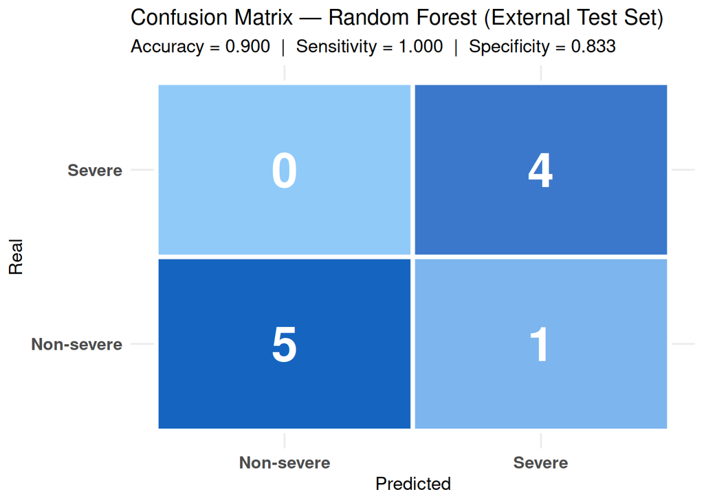

```r
#CONFUSION MATRIX VISUALIZATION

accuracy_test    <- unname(cm_test$overall["Accuracy"])
sensitivity_test <- unname(cm_test$byClass["Sensitivity"])
specificity_test <- unname(cm_test$byClass["Specificity"])

as.data.frame(cm_test$table) %>%
  rename(Predicho = Prediction, Real = Reference, N = Freq) %>%
  ggplot(aes(x = Predicho, y = Real, fill = N)) +
  geom_tile(color = "white", linewidth = 1.5) +
  geom_text(aes(label = N), size = 12, fontface = "bold", color = "white") +
  scale_fill_gradient(low = "#90CAF9", high = "#1565C0") +
  labs(
    title    = "Confusion Matrix — Random Forest (External Test Set)",
    subtitle = sprintf("Accuracy = %.3f  |  Sensitivity = %.3f  |  Specificity = %.3f",
                       accuracy_test, sensitivity_test, specificity_test),
    x = "Predicted", y = "Real"
  ) +
  theme_minimal(base_size = 13) +
  theme(
    legend.position = "none",
    axis.text = element_text(size = 12, face = "bold")
  )
```

# session info

R version 4.2.0 (2022-04-22) Platform: x86_64-conda-linux-gnu (64-bit) Running under: Ubuntu 24.04.3 LTS

Matrix products: default BLAS/LAPACK: /home/julia/miniconda3/envs/dmi/lib/libopenblasp-r0.3.30.so

locale: [1] LC_CTYPE=es_ES.UTF-8 LC_NUMERIC=C  
[3] LC_TIME=es_ES.UTF-8 LC_COLLATE=es_ES.UTF-8  
[5] LC_MONETARY=es_ES.UTF-8 LC_MESSAGES=es_ES.UTF-8  
[7] LC_PAPER=es_ES.UTF-8 LC_NAME=C  
[9] LC_ADDRESS=C LC_TELEPHONE=C  
[11] LC_MEASUREMENT=es_ES.UTF-8 LC_IDENTIFICATION=C

attached base packages: [1] stats graphics grDevices utils datasets methods base

other attached packages: [1] scales_1.4.0 pROC_1.18.5 caret_6.0-94  
[4] lattice_0.22-6 randomForest_4.7-1.1 ggplot2_4.0.1  
[7] tibble_3.2.1 tidyr_1.3.1 dplyr_1.1.4  
[10] janitor_2.2.1 readxl_1.4.3 httr_1.4.7

loaded via a namespace (and not attached): [1] sass_0.4.9 jsonlite_1.8.8 splines_4.2.0  
[4] foreach_1.5.2 prodlim_2024.06.25 bslib_0.7.0  
[7] S7_0.2.1 highr_0.11 stats4_4.2.0  
[10] cellranger_1.1.0 yaml_2.3.8 globals_0.16.3  
[13] ipred_0.9-14 pillar_1.9.0 glue_1.7.0  
[16] digest_0.6.36 RColorBrewer_1.1-3 snakecase_0.11.1  
[19] hardhat_1.4.0 recipes_1.0.10 htmltools_0.5.8.1  
[22] Matrix_1.6-5 plyr_1.8.9 timeDate_4032.109  
[25] pkgconfig_2.0.3 listenv_0.9.1 purrr_1.0.2  
[28] gower_1.0.1 lava_1.7.3 proxy_0.4-27  
[31] timechange_0.3.0 generics_0.1.3 farver_2.1.2  
[34] withr_3.0.0 cachem_1.1.0 nnet_7.3-19  
[37] cli_3.6.3 survival_3.7-0 magrittr_2.0.3  
[40] evaluate_0.24.0 fansi_1.0.6 future_1.33.2  
[43] parallelly_1.37.1 nlme_3.1-165 MASS_7.3-60.0.1  
[46] class_7.3-22 tools_4.2.0 data.table_1.15.2  
[49] lifecycle_1.0.4 stringr_1.5.1 e1071_1.7-14  
[52] compiler_4.2.0 jquerylib_0.1.4 rlang_1.1.4  
[55] grid_4.2.0 iterators_1.0.14 rstudioapi_0.16.0  
[58] labeling_0.4.3 rmarkdown_2.27 ModelMetrics_1.2.2.2 [61] gtable_0.3.6 codetools_0.2-20 curl_4.3.3  
[64] reshape2_1.4.4 R6_2.5.1 lubridate_1.9.3  
[67] knitr_1.47 fastmap_1.2.0 future.apply_1.11.2 [70] utf8_1.2.4 stringi_1.7.6 parallel_4.2.0  
[73] Rcpp_1.0.12 vctrs_0.6.5 rpart_4.1.23  
[76] tidyselect_1.2.1 xfun_0.45